# ml_project_dataset_24months

Jeanette Lee, Kevin Stadelmann, Marc Weber, Patricia Wellhöfer

02 January 2022

# 1 Introduction

Data Source: [link](https://www.kaggle.com/rikdifos/credit-card-approval-prediction) (last update: 20-03-24)

```r
library(magrittr)
library(data.table)
library(dplyr)
library(lubridate)
library(caret)
library(knitr)
library(inspectdf)
library(ggplot2)
library(GGally)
library(gridExtra) # added
library(car)  # added

opts_chunk$set(fig.align="center", echo=TRUE)

knit_hooks$set(inline=function(x) {
  prettyNum(x, big.mark=",")
})
```

# 2 Data Import and Cleaning

```r
df.ar <- fread("data/application_record.csv", stringsAsFactors = TRUE)
df.cr <- fread("data/credit_record.csv", stringsAsFactors = TRUE)
```

## 2.1 View Data

### 2.1.1 Application Record Dataframe

DAYS_BIRTH and DAYS_EMPLOYED columns count backwards from “current” day (0), -1 means yesterday, etc.  
DAYS_EMPLOYED is positive, if the person is currently unemployed.

|  | type |
| --- | --- |
| ID | integer |
| CODE_GENDER | factor |
| FLAG_OWN_CAR | factor |
| FLAG_OWN_REALTY | factor |
| CNT_CHILDREN | integer |
| AMT_INCOME_TOTAL | numeric |
| NAME_INCOME_TYPE | factor |
| NAME_EDUCATION_TYPE | factor |
| NAME_FAMILY_STATUS | factor |
| NAME_HOUSING_TYPE | factor |
| DAYS_BIRTH | integer |
| DAYS_EMPLOYED | integer |
| FLAG_MOBIL | integer |
| FLAG_WORK_PHONE | integer |
| FLAG_PHONE | integer |
| FLAG_EMAIL | integer |
| OCCUPATION_TYPE | factor |
| CNT_FAM_MEMBERS | numeric |

| ID | CODE_GENDER | FLAG_OWN_CAR | FLAG_OWN_REALTY | CNT_CHILDREN | AMT_INCOME_TOTAL | NAME_INCOME_TYPE | NAME_EDUCATION_TYPE | NAME_FAMILY_STATUS | NAME_HOUSING_TYPE | DAYS_BIRTH | DAYS_EMPLOYED | FLAG_MOBIL | FLAG_WORK_PHONE | FLAG_PHONE | FLAG_EMAIL | OCCUPATION_TYPE | CNT_FAM_MEMBERS |
| --- | --- | --- | --- | --- | --- | --- | --- | --- | --- | --- | --- | --- | --- | --- | --- | --- | --- |
| 5008804 | M | Y | Y | 0 | 427500 | Working | Higher education | Civil marriage | Rented apartment | -12005 | -4542 | 1 | 1 | 0 | 0 |  | 2 |
| 5008805 | M | Y | Y | 0 | 427500 | Working | Higher education | Civil marriage | Rented apartment | -12005 | -4542 | 1 | 1 | 0 | 0 |  | 2 |
| 5008806 | M | Y | Y | 0 | 112500 | Working | Secondary / secondary special | Married | House / apartment | -21474 | -1134 | 1 | 0 | 0 | 0 | Security staff | 2 |
| 5008808 | F | N | Y | 0 | 270000 | Commercial associate | Secondary / secondary special | Single / not married | House / apartment | -19110 | -3051 | 1 | 0 | 1 | 1 | Sales staff | 1 |
| 5008809 | F | N | Y | 0 | 270000 | Commercial associate | Secondary / secondary special | Single / not married | House / apartment | -19110 | -3051 | 1 | 0 | 1 | 1 | Sales staff | 1 |
| 5008810 | F | N | Y | 0 | 270000 | Commercial associate | Secondary / secondary special | Single / not married | House / apartment | -19110 | -3051 | 1 | 0 | 1 | 1 | Sales staff | 1 |

### 2.1.2 Credit Record Dataframe

MONTHS_BALANCE column counts backward from “current” month (0), -1 = previous month, -2 = 2 months prior, etc.  
STATUS column: 0 = 1-29 days past due, 1 = 30-59 days past due, 2 = 60-89 days overdue, 3 = 90-119 days overdue, 4 = 120-149 days overdue, 5 = Overdue or bad debts, write-offs for more than 150 days, C = paid off that month, X = No loan for the month

|  | type |
| --- | --- |
| ID | integer |
| MONTHS_BALANCE | integer |
| STATUS | factor |

| ID | MONTHS_BALANCE | STATUS |
| --- | --- | --- |
| 5001711 | 0 | X |
| 5001711 | -1 | 0 |
| 5001711 | -2 | 0 |
| 5001711 | -3 | 0 |
| 5001712 | 0 | C |
| 5001712 | -1 | C |

## 2.2 Clean Data

### 2.2.1 Cleaning application_record.csv

Remove duplicate IDs from application_record.csv

```r
df.ar$ID %>% unique() %>% length()
## [1] 438510

duplicates <- df.ar %>% group_by(ID) %>% summarise(count = n()) %>% filter(count > 1)
df.ar.mod <- df.ar %>% filter(!ID %in% duplicates$ID)

df.ar.mod$ID %>% unique() %>% length()
## [1] 438463
```

### 2.2.2 Cleaning credit_record.csv

The original dataset was made available on 2020-03-24, so it is presumed current month is March 2020. From months_balance we create 2 new columns indicating the month and year for each observation. Observations older than 2 years are removed.

```r
# Extract month and year from months_balance in df.cr
df.cr$month_balance <- format(as.Date("2020-03-24") %m+% months(df.cr$MONTHS_BALANCE), "%B")
df.cr$year_balance <- format(as.Date("2020-03-24") %m+% months(df.cr$MONTHS_BALANCE), "%Y") %>% as.integer(.)

# Remove records older than 2 years
df.cr.mod <- df.cr %>% filter(MONTHS_BALANCE > -24)

# Assign customer status
df.status <- df.cr.mod %>%
  group_by(ID) %>%
  summarise(cnt_status_good = length(STATUS[STATUS==0|STATUS==1|STATUS=='C']),
            cnt_status_bad = n() - cnt_status_good,
            percent_good = round(cnt_status_good / n() * 100),
            percent_bad = round(cnt_status_bad / n() * 100)) %>%
  mutate(
    customer_status_good = ifelse(percent_good >= 50, 1, 0)
  ) %>%
  select(ID, customer_status_good, percent_good)

df.status$customer_status_good <- as.factor(df.status$customer_status_good)
```

### 2.2.3 Join datasets

The two cleaned datasets are joined and only records where IDs exist in both are kept.

```r
df.cc.raw <- inner_join(x = df.status, y = df.ar.mod, by = "ID") %>%
  mutate(ID = as.factor(ID),
         CNT_FAM_MEMBERS = as.integer(CNT_FAM_MEMBERS),
         age_years = as.numeric(round(DAYS_BIRTH * (-1) / 365.25), 0),         # instead of DAYS_BIRTH
         work_years = as.numeric(round((DAYS_EMPLOYED * (-1) / 365.25), 0)),   # instead of DAYS_EMPLOYED, negative: Pensioner
         FLAG_MOBIL = as.factor(FLAG_MOBIL),
         FLAG_WORK_PHONE = as.factor(FLAG_WORK_PHONE),
         FLAG_PHONE = as.factor(FLAG_PHONE),
         FLAG_EMAIL = as.factor(FLAG_EMAIL))

# Change column names to lower case
setnames(df.cc.raw, tolower(names(df.cc.raw)))

# Look at the factor levels
df.cc.raw %>%
  select(-id) %>%
  select_if(is.factor) %>%
  sapply(., FUN = levels)
```

```
## $customer_status_good
## [1] "0" "1"
##
## $code_gender
## [1] "F" "M"
##
## $flag_own_car
## [1] "N" "Y"
##
## $flag_own_realty
## [1] "N" "Y"
##
## $name_income_type
## [1] "Commercial associate" "Pensioner"            "State servant"
## [4] "Student"              "Working"
##
## $name_education_type
## [1] "Academic degree"               "Higher education"
## [3] "Incomplete higher"             "Lower secondary"
## [5] "Secondary / secondary special"
##
## $name_family_status
## [1] "Civil marriage"       "Married"              "Separated"
## [4] "Single / not married" "Widow"
##
## $name_housing_type
## [1] "Co-op apartment"     "House / apartment"   "Municipal apartment"
## [4] "Office apartment"    "Rented apartment"    "With parents"
##
## $flag_mobil
## [1] "1"
##
## $flag_work_phone
## [1] "0" "1"
##
## $flag_phone
## [1] "0" "1"
##
## $flag_email
## [1] "0" "1"
##
## $occupation_type
##  [1] ""                      "Accountants"           "Cleaning staff"
##  [4] "Cooking staff"         "Core staff"            "Drivers"
##  [7] "HR staff"              "High skill tech staff" "IT staff"
## [10] "Laborers"              "Low-skill Laborers"    "Managers"
## [13] "Medicine staff"        "Private service staff" "Realty agents"
## [16] "Sales staff"           "Secretaries"           "Security staff"
## [19] "Waiters/barmen staff"
```

```r
# flag_mobil = 1 for all IDs => exclude from final dataset

# occupation_type has "" level => replace with NA
levels(df.cc.raw$occupation_type)[levels(df.cc.raw$occupation_type)==""] <- "NA"
# df.cc.raw$occupation_type %>% table()                                        # check that "" are updated as NA

# Set order of levels in education type
df.cc.raw$name_education_type <- factor(df.cc.raw$name_education_type, levels=c("Lower secondary", "Secondary / secondary special", "Incomplete higher", "Higher education", "Academic degree"), ordered = TRUE)

# Convert -ve values to NA
df.cc.raw$work_years[df.cc.raw$work_years == '-1000'] <- NA

# Select columns
# months_balance, days_birth, days_employed and flag_mobil columns are excluded
df.cc <- df.cc.raw %>%
  select(id,
         code_gender,
         age_years,
         name_education_type,
         name_income_type,
         name_housing_type,
         name_family_status,
         cnt_children,
         cnt_fam_members,
         flag_own_car,
         flag_own_realty,
         work_years,
         amt_income_total,
         occupation_type,
         flag_work_phone,
         flag_phone,
         flag_email,
         customer_status_good,
         percent_good)
```

### 2.2.4 Remove duplicates

Remove additional duplicates. Even tough entries have different ID’s, all the other columns are the same. That’s why we only keep the unique ID’s, which also have uniqueness in all the other columns.

```r
df.cc <- df.cc[!duplicated(df.cc[c(2:17)]),]

# remove NA-values
df.cc <- na.omit(df.cc)

# remove dataframes which are not used anymore
rm("df.ar", "df.ar.mod", "df.cc.raw", "df.cr", "df.cr.mod", "df.status", "duplicates")
```

### 2.2.5 Check Final Dataframe

```r
# Meta information from df.cc
nlevels(df.cc$id)
## [1] 32848

str(df.cc)
## tibble [7,839 x 19] (S3: tbl_df/tbl/data.frame)
##  $ id                  : Factor w/ 32848 levels "5008804","5008805",..: 1 3 4 11 12 18 21 24 25 27 ...
##  $ code_gender         : Factor w/ 2 levels "F","M": 2 2 1 2 2 1 1 1 2 2 ...
##  $ age_years           : num [1:7839] 33 59 52 46 49 29 27 30 35 32 ...
##  $ name_education_type : Ord.factor w/ 5 levels "Lower secondary"<..: 4 2 2 4 2 3 2 2 2 4 ...
##  $ name_income_type    : Factor w/ 5 levels "Commercial associate",..: 5 5 1 5 1 5 5 5 5 1 ...
##  $ name_housing_type   : Factor w/ 6 levels "Co-op apartment",..: 5 2 2 2 2 2 2 2 2 2 ...
##  $ name_family_status  : Factor w/ 5 levels "Civil marriage",..: 1 2 4 2 2 2 2 4 2 2 ...
##  $ cnt_children        : int [1:7839] 0 0 0 0 0 0 0 1 3 1 ...
##  $ cnt_fam_members     : int [1:7839] 2 2 1 2 2 2 2 2 5 3 ...
##  $ flag_own_car        : Factor w/ 2 levels "N","Y": 2 2 1 2 2 2 1 1 2 1 ...
##  $ flag_own_realty     : Factor w/ 2 levels "N","Y": 2 2 2 2 2 1 2 2 2 2 ...
##  $ work_years          : num [1:7839] 12 3 8 2 3 3 4 4 3 6 ...
##  $ amt_income_total    : num [1:7839] 427500 112500 270000 270000 135000 ...
##  $ occupation_type     : Factor w/ 19 levels "NA","Accountants",..: 1 18 16 2 10 2 10 1 10 12 ...
##  $ flag_work_phone     : Factor w/ 2 levels "0","1": 2 1 1 2 1 1 1 1 1 1 ...
##  $ flag_phone          : Factor w/ 2 levels "0","1": 1 1 2 2 1 1 2 1 1 1 ...
##  $ flag_email          : Factor w/ 2 levels "0","1": 1 1 2 2 1 1 1 1 1 1 ...
##  $ customer_status_good: Factor w/ 2 levels "0","1": 2 2 1 2 1 2 2 2 2 2 ...
##  $ percent_good        : num [1:7839] 94 50 40 100 0 100 100 100 100 93 ...
##  - attr(*, "na.action")= 'omit' Named int [1:1502] 4 8 18 26 36 42 58 60 64 76 ...
##   ..- attr(*, "names")= chr [1:1502] "4" "8" "18" "26" ...

head(df.cc) %>% kable()
```

| id | code_gender | age_years | name_education_type | name_income_type | name_housing_type | name_family_status | cnt_children | cnt_fam_members | flag_own_car | flag_own_realty | work_years | amt_income_total | occupation_type | flag_work_phone | flag_phone | flag_email | customer_status_good | percent_good |
| --- | --- | --- | --- | --- | --- | --- | --- | --- | --- | --- | --- | --- | --- | --- | --- | --- | --- | --- |
| 5008804 | M | 33 | Higher education | Working | Rented apartment | Civil marriage | 0 | 2 | Y | Y | 12 | 427500 | NA | 1 | 0 | 0 | 1 | 94 |
| 5008806 | M | 59 | Secondary / secondary special | Working | House / apartment | Married | 0 | 2 | Y | Y | 3 | 112500 | Security staff | 0 | 0 | 0 | 1 | 50 |
| 5008808 | F | 52 | Secondary / secondary special | Commercial associate | House / apartment | Single / not married | 0 | 1 | N | Y | 8 | 270000 | Sales staff | 0 | 1 | 1 | 0 | 40 |
| 5008815 | M | 46 | Higher education | Working | House / apartment | Married | 0 | 2 | Y | Y | 2 | 270000 | Accountants | 1 | 1 | 1 | 1 | 100 |
| 5008819 | M | 49 | Secondary / secondary special | Commercial associate | House / apartment | Married | 0 | 2 | Y | Y | 3 | 135000 | Laborers | 0 | 0 | 0 | 0 | 0 |
| 5008825 | F | 29 | Incomplete higher | Working | House / apartment | Married | 0 | 2 | Y | N | 3 | 130500 | Accountants | 0 | 0 | 0 | 1 | 100 |

```r
#df.cc %>% inspect_cat() %>% show_plot()
```

# 3 Model 1: Linear Model

Predictive Model: How do socio-economic variables influence an individual’s behaviour in paying off their credit balance? The scope of this analysis is to be able to preidct the percentage of times that an individual pays off their credit balance within 60 days.

## 3.1 Graphical Analysis

### 3.1.1 Continuous Variables

We start the graphical analysis by plotting the response variable (i.e. percent_good) against the predictor age (i.e. age_years).

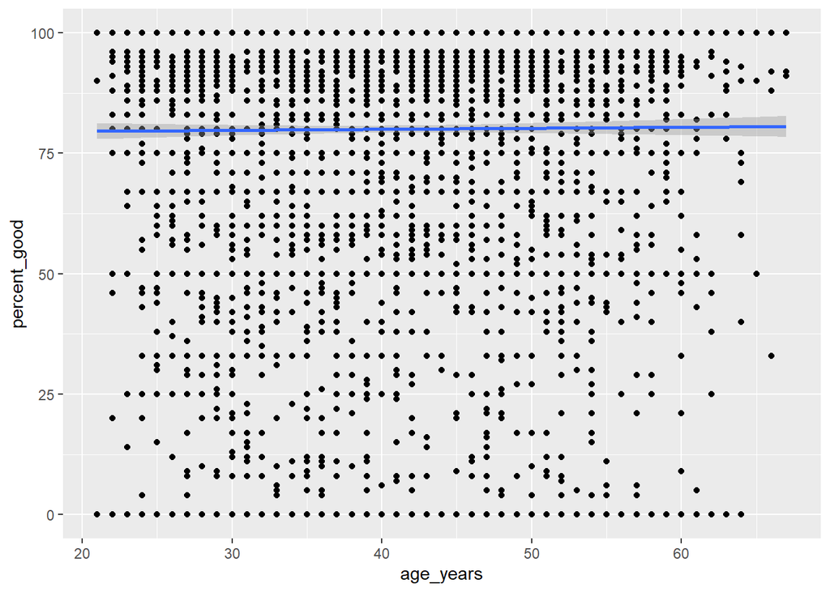

```r
ggplot(data = df.cc, mapping = aes(y = percent_good, x = age_years)) +
  geom_point() + geom_smooth(method="lm")
```

There seems to be a slight positive relationship between these two variables.

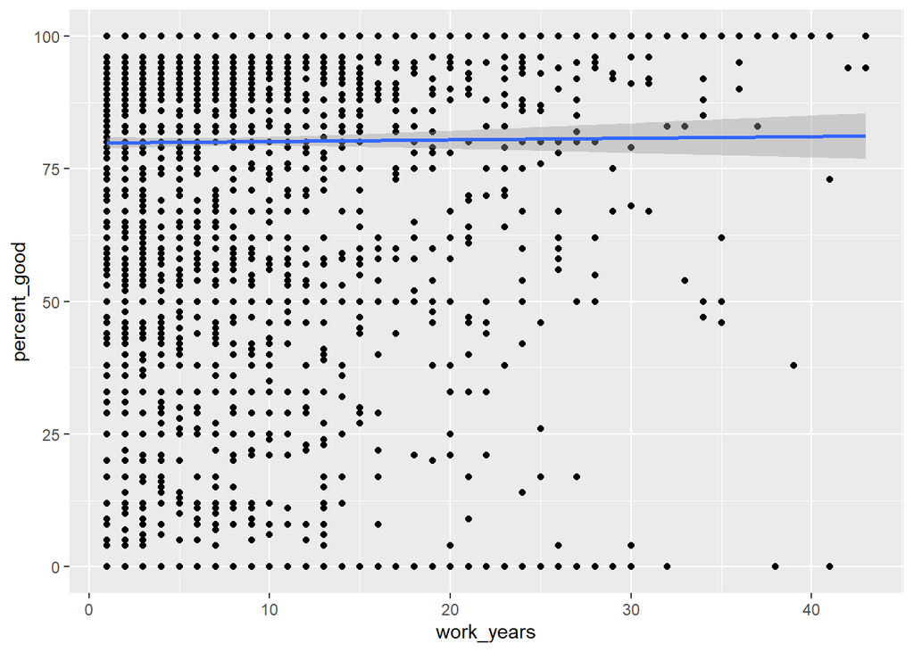

```r
ggplot(data = subset(df.cc, work_years > 0), mapping = aes(y = percent_good, x = work_years)) +
  geom_point() + geom_smooth(method="lm")   # default applies 'gam' method, but still no obvious relationship
```

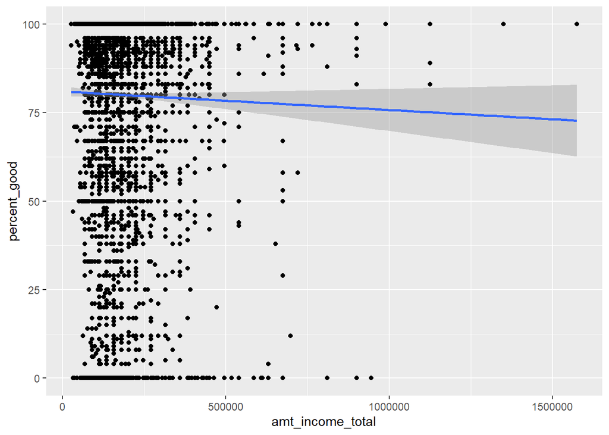

```r
ggplot(data = df.cc, mapping = aes(y = percent_good, x = amt_income_total)) +
  geom_point() + geom_smooth(method="lm")   # default applies 'gam' method which suggests a possible non-linear relationship
```

Here, we can see that there are few accounts (26) with a total income above 750K, it would be recommended to omit or recenter focus for regression as accuracy of the prediction would be reduced in this higher income range.

We see that there are few individuals with academic degrees, so we group them with higher education.

```r
df.cc$name_education_type <- recode_factor(df.cc$name_education_type, "Academic degree" = "Higher education")
df.cc$name_education_type <- factor(df.cc$name_education_type, levels=c("Lower secondary", "Secondary / secondary special", "Incomplete higher", "Higher education"), ordered = TRUE)
```

### 3.1.3 Categorical Variables

Next we plot the categorical variables against our dependent variable. The boxplots indicate that the median for name_education_type, name_housing_type, name_family_status, occupation_type, and flag_realty are the same (100%), however their factor levels differ in spread. This suggests there may exist a relationship between these variables and the dependent variable.

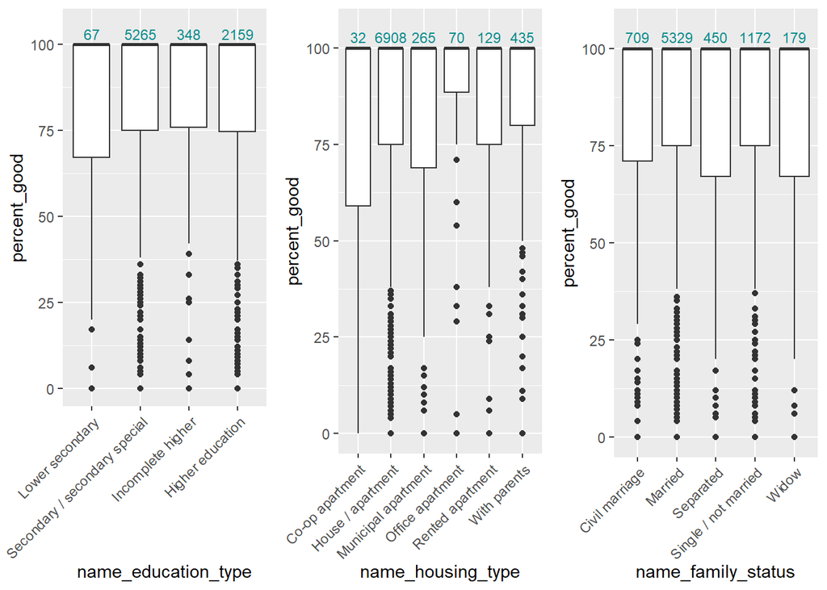

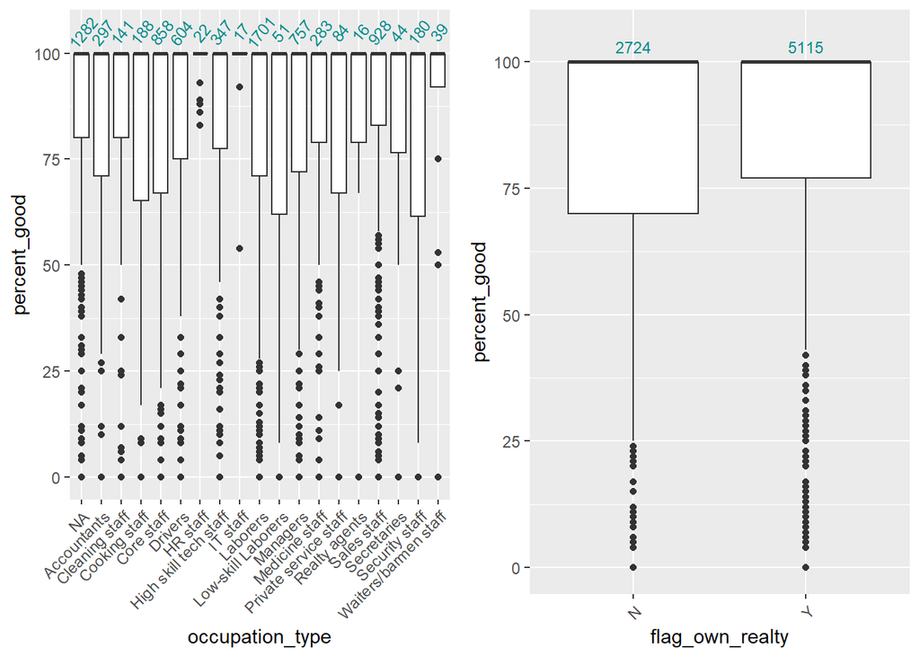

```r
plot.ed <- ggplot(data = df.cc, mapping = aes(y = percent_good, x = name_education_type)) +
  geom_boxplot() + theme(axis.text.x=element_text(angle=45, hjust=1)) +
  geom_text(aes(label = ..count..), y = 103, stat = "count", size = 3, color="darkcyan") + coord_cartesian(ylim=c(0,105))

plot.housing <- ggplot(data = df.cc, mapping = aes(y = percent_good, x = name_housing_type)) +
  geom_boxplot() + theme(axis.text.x=element_text(angle=45, hjust=1)) +
  geom_text(aes(label = ..count..), y = 103, stat = "count", size = 3, color="darkcyan") + coord_cartesian(ylim=c(0,105))

plot.occupation <- ggplot(data = df.cc, mapping = aes(y = percent_good,x = occupation_type)) +
  geom_boxplot() + theme(axis.text.x=element_text(angle=45, hjust=1)) +
  geom_text(aes(label = ..count..), y = 105, stat = "count", size = 3, color="darkcyan", angle = 50) + coord_cartesian(ylim=c(0,105))

plot.famstatus <- ggplot(data = df.cc, mapping = aes(y = percent_good, x = name_family_status)) +
  geom_boxplot() + theme(axis.text.x=element_text(angle=45, hjust=1)) +
  geom_text(aes(label = ..count..), y = 103, stat = "count", size = 3, color="darkcyan") + coord_cartesian(ylim=c(0,105))

plot.realty <- ggplot(data = df.cc, mapping = aes(y = percent_good, x = flag_own_realty)) +
  geom_boxplot() + theme(axis.text.x=element_text(angle=45, hjust=1)) +
  geom_text(aes(label = ..count..), y = 103, stat = "count", size = 3, color="darkcyan") + coord_cartesian(ylim=c(0,105))
```

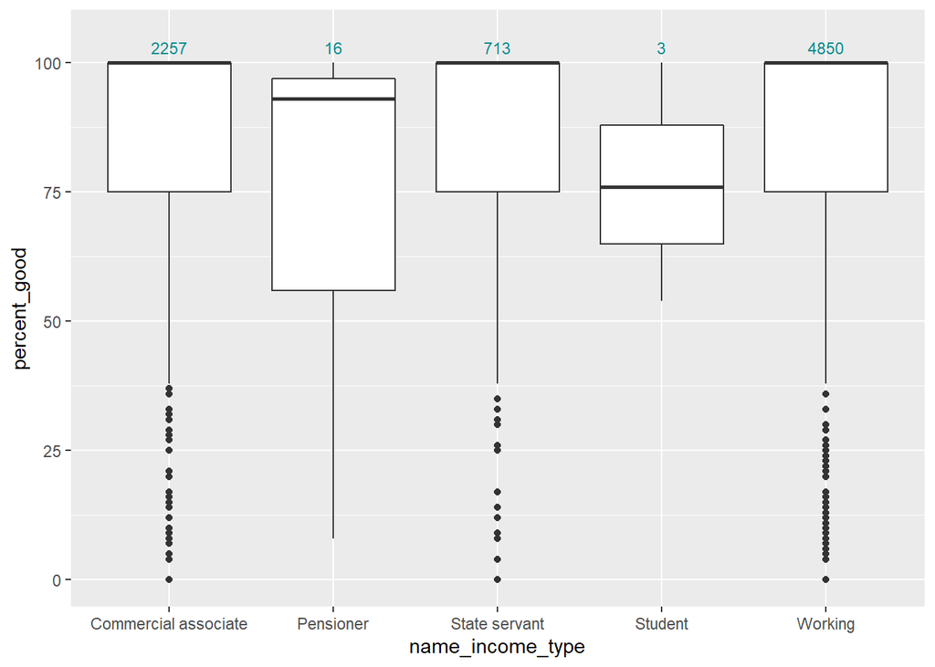

```r
ggplot(data = df.cc, mapping = aes(y = percent_good, x = name_income_type)) + geom_boxplot() +
  geom_text(aes(label = ..count..), y = 103, stat = "count", size = 3, color="darkcyan") + coord_cartesian(ylim=c(0,105))
```

### 3.1.4 Count Variables

Plotting our two count variables, we see some outliers (cnt_children > 5, cnt_fam_members > 7), which we consider removing from the dataset as these are fringe cases that are unlikely to come up often.

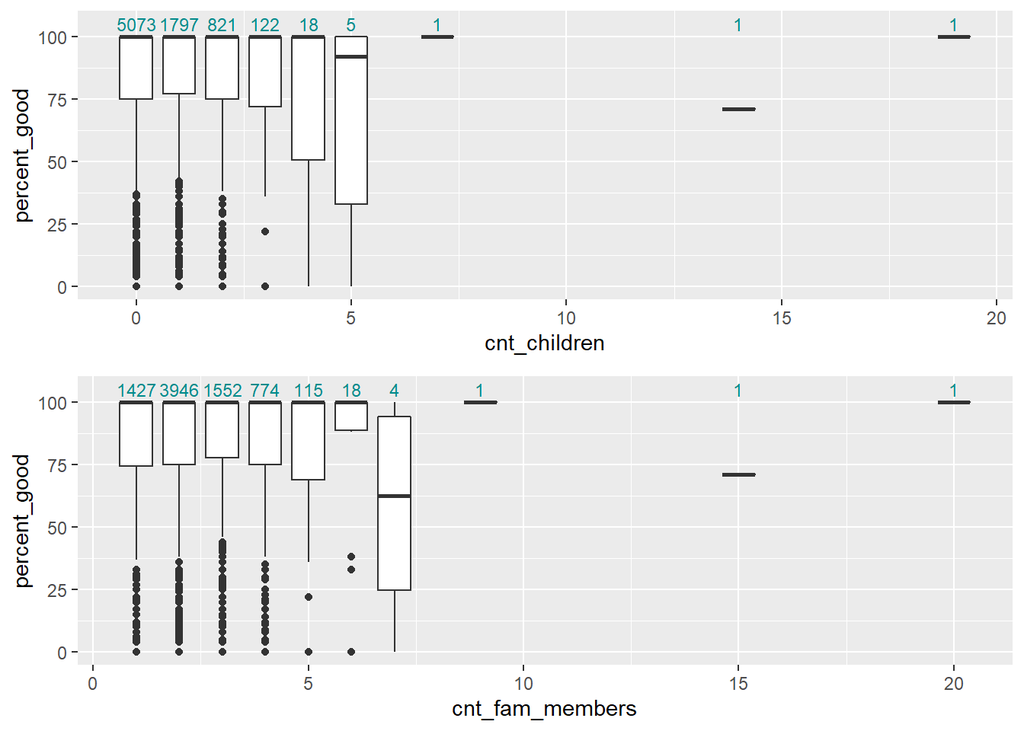

```r
plot.children <- ggplot(data = df.cc, mapping = aes(y = percent_good, x = cnt_children, group = as.factor(cnt_children))) + geom_boxplot() +
  geom_text(aes(label = ..count..), y = 105, stat = "count", size = 3, color="darkcyan") + coord_cartesian(ylim=c(0,105))

plot.family <- ggplot(data = df.cc, mapping = aes(y = percent_good, x = cnt_fam_members, group = as.factor(cnt_fam_members))) + geom_boxplot() +
  geom_text(aes(label = ..count..), y = 105, stat = "count", size = 3, color="darkcyan") + coord_cartesian(ylim=c(0,105))

grid.arrange(plot.children, plot.family, nrow=2)
```

### 3.1.5 Colinearity

With a few of the variables, there is the possibility of colinearity, specifically between age_years and work_years, and cnt_fam_members and cnt_children. We inspect this by plotting the variables against one another.

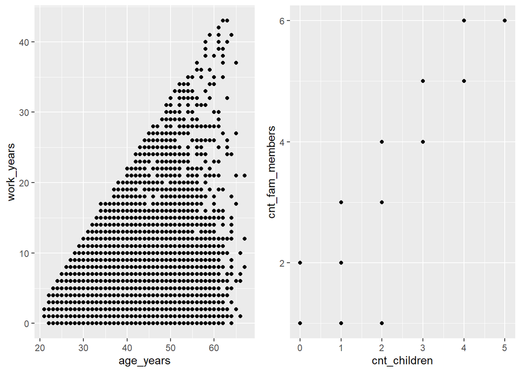

```r
plot.c.years <- ggplot(data = df.cc.new, mapping = aes(y = work_years, x = age_years)) + geom_point()

plot.c.family <- ggplot(data = df.cc.new, mapping = aes(y = cnt_fam_members, x = cnt_children)) + geom_point()

grid.arrange(plot.c.years, plot.c.family, ncol=2)
```

```r
# consider removing?
vif(lm(percent_good ~ age_years + work_years, data = df.cc.new))
```

```
##  age_years work_years
##   1.136056   1.136056
```

```r
vif(lm(percent_good ~ cnt_children + cnt_fam_members, data = df.cc.new))
```

```
##    cnt_children cnt_fam_members
##        5.011578        5.011578
```

### 3.1.6 Interactions

Next we investigate whether there are interactions between the variables previously identified.

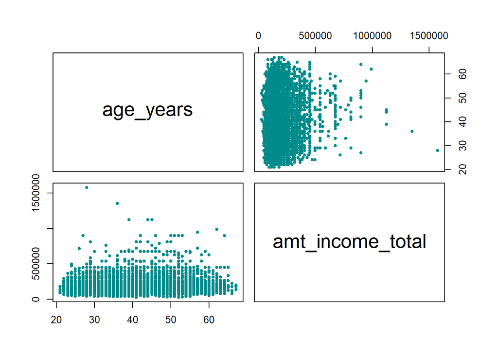

```r
## variables to consider as IVs: ##
# continuous: age_years, amt_income_total
# count: cnt_fam_members
# categorical: name_education_type, name_housing_type, occupation_type, name_family_status, name_income_type

pairs(~ age_years + amt_income_total, data = subset(df.cc.new, work_years > 0), pch = 20, col = "darkcyan")
```

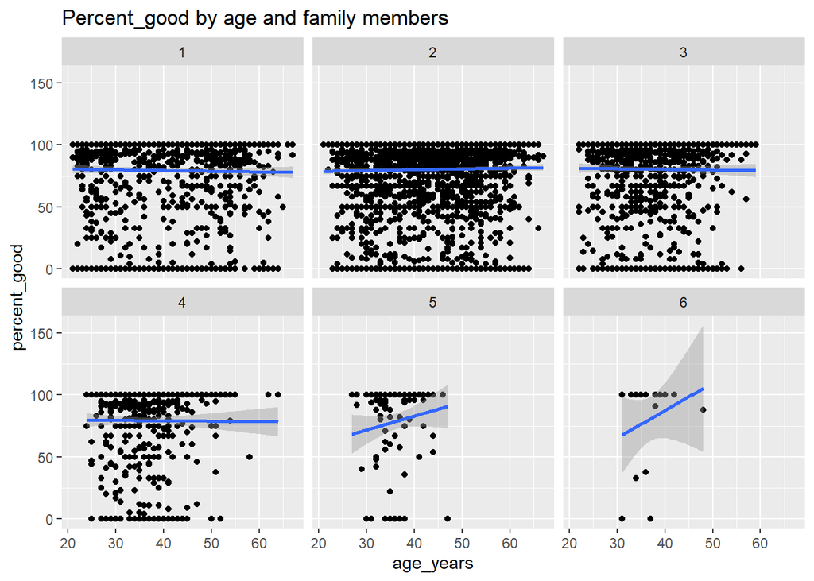

```r
# there seems to be no interaction between age_years and amt_income_total

ggplot(data = df.cc.new, mapping = aes(y = percent_good, x = age_years, group = as.factor(cnt_fam_members))) +
  geom_point() + geom_smooth(method="lm") + facet_wrap(~as.factor(cnt_fam_members)) + ggtitle("Percent_good by age and family members")
```

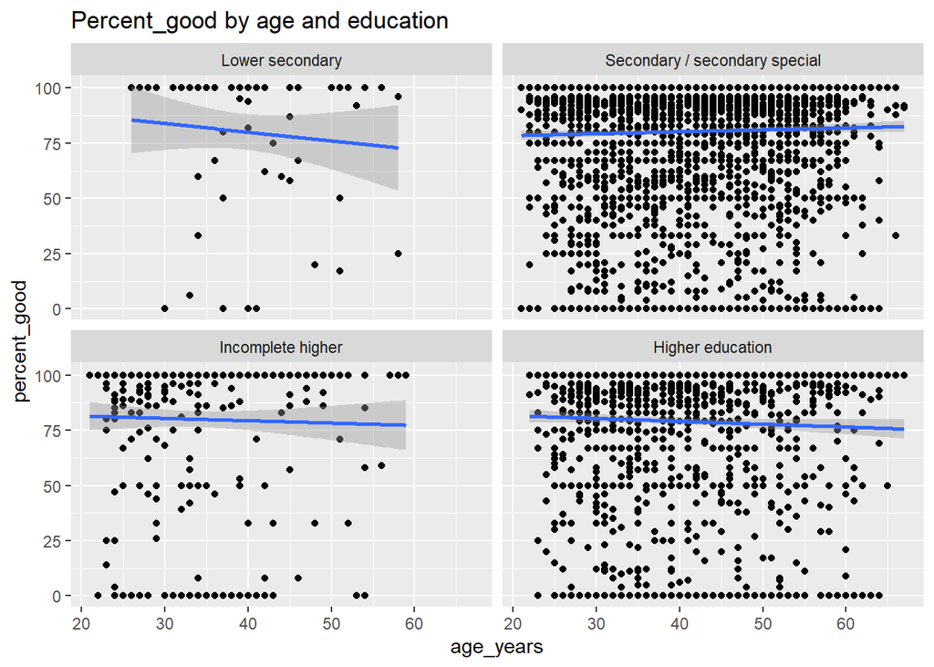

```r
# note: lack of data for cnt_fam_members for age < 25 and age > 50 when making predictions

ggplot(data = df.cc.new, mapping = aes(y = percent_good, x = age_years, group = name_education_type)) +
  geom_point() + geom_smooth(method="lm") + facet_wrap(~name_education_type) + ggtitle("Percent_good by age and education")
```